# BST260 Final Report

Nick Birk

12/15/2019

## Introduction

Food security is a major public health concern. In order for people to live their healthiest lives, they must be able to access fresh produce. During my undergraduate studies, I worked part-time as a gardener and at a farmer’s market for two years, so food systems are of personal interest to me. During my time working these jobs, I learned about the way in which outside factors can largely influence an individual’s ability to access foods which are considered healthy. My hope is to observe what factors can predict the availability of various fruits and vegetables. Through this investigation, we may gain an understanding of what external forces are associated with the stability of our food systems and the health-related decisions that individuals are able to make.

One of the main priorities for this project is to create an interactive way to observe the trends of food availability over time, and how these metrics are associated with external factors. Such factors include real gross domestic product, diabetes prevalence, and unemployment rate. The ideal way to explore these trends would be through a Shiny app. In one tab, I will provide an interactive way to observe trends over time for a vegetable or fruit of choice, and in a second tab, I will provide an opportunity for the user to observe how availability correlates with other factors through scatterplots. Additionally, I hope to implement regression analyses to create a predictive system for food availability and consumption.

# Data Assembly

```r
if(!require(tidyverse)) install.packages('tidyverse')
library(tidyverse)

#Total fruit and vegetable data
fruitveg <- read.csv('fruitveg.csv')
colnames(fruitveg)[1] <- 'year'

#Specific fruits and vegetables
apples <- read.csv('apples.csv')
avocados <- read.csv('avocados.csv')
bananas <- read.csv('bananas.csv')
bellpeppers <- read.csv('bellpeppers.csv')
broccoli <- read.csv('broccoli.csv')
cabbage <- read.csv('cabbage.csv')
carrots <- read.csv('carrots.csv')
eggplant <- read.csv('eggplant.csv')
grapes <- read.csv('grapes.csv')
lemons <- read.csv('lemons.csv')
mushrooms <- read.csv('mushrooms.csv')
onions <- read.csv('onions.csv')
oranges <- read.csv('oranges.csv')
peaches <- read.csv('peaches.csv')
pears <- read.csv('pears.csv')
pineapples <- read.csv('pineapples.csv')
potatoes <- read.csv('potatoes.csv')
spinach <- read.csv('spinach.csv')
tomatoes <- read.csv('tomatoes.csv')
watermelon <- read.csv('watermelon.csv')
```

Now, we can read in the data for potential covariates. Potential predictors included in the analysis were diabetes prevalence (available from the Centers for Disease Control and Prevention), average annual farm income (available from the US Department of Agriculture), annual unemployment rate (available from the US Bureau of Labor Statistics), percent GDP spending on healthcare (available from the Centers for Medicare and Medicaid Services), average life expectancy, population, and GDP (available from the Gapminder foundation).

```r
covariates <- read.csv('covariates.csv')
```

Note that farm income is in terms of 2019 dollars (i.e. adjusted for inflation).

```r
if(!require(dslabs)) install.packages('dslabs')
library(dslabs)

usgapminder <- gapminder %>%
  filter(year %in% c(1970:2017) & country == 'United States') %>%
  dplyr::select('year', 'life_expectancy', 'population', 'gdp')

covariates2 <- full_join(covariates, usgapminder, by = 'year')

#View(covariates2)
```

Now, we may combine the separate datasets. For purposes of linear regression, we want one form of the table in which every row represents a year. For purposes of visualization in the Shiny app, we want a second data frame in which every row represents a specific year-variable pairing.

```r
#First, we will join all tables on year
dat_annual <- full_join(fruitveg, covariates2, by = 'year')

head(dat_annual)
```

```
##   year fruit_fresh fruit_processed veg_fresh veg_processed total_fruit
## 1 1970       100.6           137.4     154.4         181.9       238.0
## 2 1971       100.8           141.6     148.1         191.5       242.4
## 3 1972        94.4           137.7     151.4         186.4       232.0
## 4 1973        96.7           139.3     148.1         187.4       236.0
## 5 1974        96.1           139.8     146.2         188.1       235.8
## 6 1975       101.3           151.2     149.1         189.8       252.5
##   total_veg total_fruit_veg diabetes_percent farm_income unemployment
## 1     336.3           574.3               NA   106425804          4.9
## 2     339.5           581.9               NA   115617438          5.9
## 3     337.8           569.8               NA   122765667          5.6
## 4     335.5           571.5             2.04   193092904          4.9
## 5     334.3           570.1               NA   202306583          5.6
## 6     338.9           591.4             2.29   189826467          8.5
##   healthcare_percgdp life_expectancy population          gdp
## 1               6.23           70.92  209485807 3.737877e+12
## 2               6.37           71.24  211357912 3.867133e+12
## 3               6.50           71.34  213219515 4.080668e+12
## 4               6.52           71.54  215092900 4.321881e+12
## 5               6.84           72.08  217001865 4.299437e+12
## 6               7.17           72.68  218963561 4.291009e+12
```

```r
#Now we create the dataset for our time series plots
dat_series <- inner_join(bananas, peaches, by = 'year')
colnames(dat_series)[2:3] <- c('bananas', 'peaches')
dat_series <- inner_join(dat_series, apples, by = 'year')
colnames(dat_series)[4] <- 'apples'
dat_series <- inner_join(dat_series, avocados, by = 'year')
colnames(dat_series)[5] <- 'avocados'
dat_series <- inner_join(dat_series, bellpeppers, by = 'year')
colnames(dat_series)[6] <- 'bellpeppers'
dat_series <- inner_join(dat_series, broccoli, by = 'year')
colnames(dat_series)[7] <- 'broccoli'
dat_series <- inner_join(dat_series, cabbage, by = 'year')
colnames(dat_series)[8] <- 'cabbage'
dat_series <- inner_join(dat_series, carrots, by = 'year')
colnames(dat_series)[9] <- 'carrots'
dat_series <- inner_join(dat_series, eggplant, by = 'year')
colnames(dat_series)[10] <- 'eggplant'
dat_series <- inner_join(dat_series, grapes, by = 'year')
colnames(dat_series)[11] <- 'grapes'
dat_series <- inner_join(dat_series, lemons, by = 'year')
colnames(dat_series)[12] <- 'lemons'
dat_series <- inner_join(dat_series, mushrooms, by = 'year')
colnames(dat_series)[13] <- 'mushrooms'
dat_series <- inner_join(dat_series, onions, by = 'year')
colnames(dat_series)[14] <- 'onions'
dat_series <- inner_join(dat_series, oranges, by = 'year')
colnames(dat_series)[15] <- 'oranges'
dat_series <- inner_join(dat_series, pears, by = 'year')
colnames(dat_series)[16] <- 'pears'
dat_series <- inner_join(dat_series, pineapples, by = 'year')
colnames(dat_series)[17] <- 'pineapples'
dat_series <- inner_join(dat_series, potatoes, by = 'year')
colnames(dat_series)[18] <- 'potatoes'
dat_series <- inner_join(dat_series, spinach, by = 'year')
colnames(dat_series)[19] <- 'spinach'
dat_series <- inner_join(dat_series, tomatoes, by = 'year')
colnames(dat_series)[20] <- 'tomatoes'
dat_series <- inner_join(dat_series, watermelon, by = 'year')
colnames(dat_series)[21] <- 'watermelon'


#Now we will include the emoji codes for each specific item
#This will come into play later!

dat_series <- gather(dat_series, fruit, value, bananas:watermelon)

dat_series$emoji_code <- ''

dat_series$emoji_code[dat_series$fruit == 'bananas'] <- '1f34c'
dat_series$emoji_code[dat_series$fruit == 'peaches'] <- '1f351'
dat_series$emoji_code[dat_series$fruit == 'apples'] <- '1f34e'
dat_series$emoji_code[dat_series$fruit == 'avocados'] <- '1f951'
dat_series$emoji_code[dat_series$fruit == 'bellpeppers'] <- '1f336'
dat_series$emoji_code[dat_series$fruit == 'broccoli'] <- '1f966'
dat_series$emoji_code[dat_series$fruit == 'cabbage'] <-'1f957'
dat_series$emoji_code[dat_series$fruit == 'carrots'] <-'1f955'
dat_series$emoji_code[dat_series$fruit == 'eggplant'] <-'1f346'
dat_series$emoji_code[dat_series$fruit == 'grapes'] <-'1f347'
dat_series$emoji_code[dat_series$fruit == 'lemons'] <-'1f34b'
dat_series$emoji_code[dat_series$fruit == 'mushrooms'] <-'1f344'
dat_series$emoji_code[dat_series$fruit == 'onions'] <-'1f348'
dat_series$emoji_code[dat_series$fruit == 'oranges'] <-'1f34a'
dat_series$emoji_code[dat_series$fruit == 'pears'] <-'1f350'
dat_series$emoji_code[dat_series$fruit == 'pineapples'] <-'1f34d'
dat_series$emoji_code[dat_series$fruit == 'potatoes'] <-'1f954'
dat_series$emoji_code[dat_series$fruit == 'spinach'] <-'1f343'
dat_series$emoji_code[dat_series$fruit == 'tomatoes'] <-'1f345'
dat_series$emoji_code[dat_series$fruit == 'watermelon'] <-'1f349'
```

# Linear Regression Analysis

First, considering we wish to run a linear regression to predict produce availability, it would be helpful to check for potential correlation between all variables. In this way, we may avoid including multicollinear covariates.

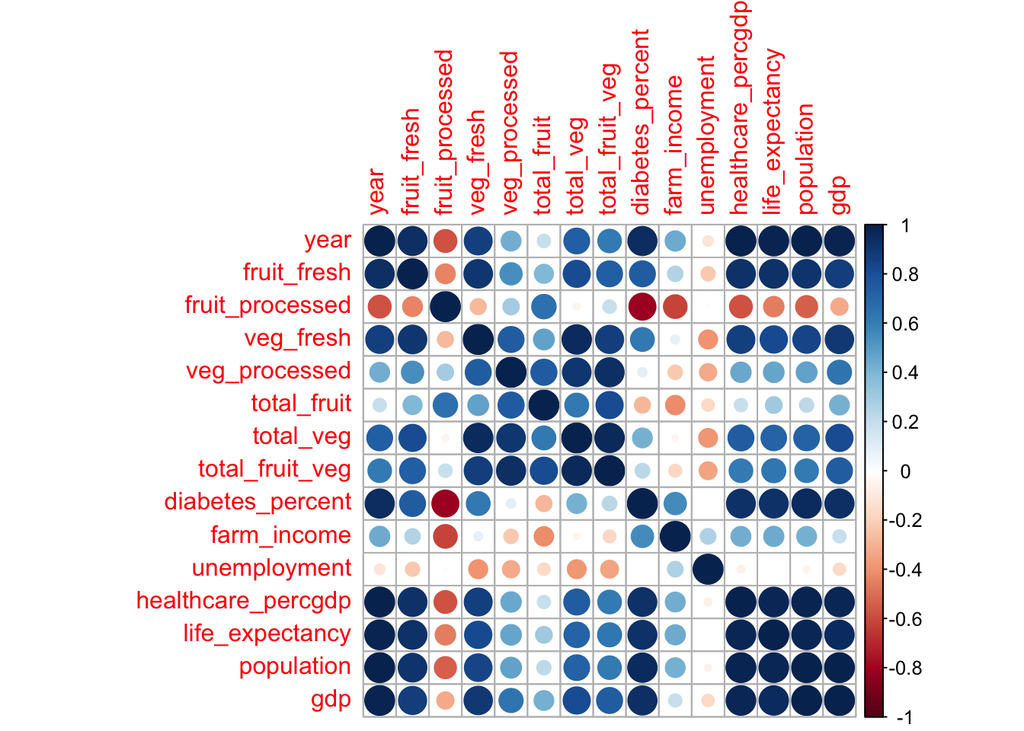

```r
if(!require(corrplot)) install.packages('corrplot')
library(corrplot)
annualcor <-cor(dat_annual, use = 'pairwise.complete.obs')
corrplot(annualcor)
```

```r
cormat <- cor(dat_annual, use = 'pairwise.complete.obs')
cormat[8,]
```

```
##               year        fruit_fresh    fruit_processed
##          0.6101829          0.7390480          0.1982480
##          veg_fresh      veg_processed        total_fruit
##          0.8740247          0.9354753          0.8192517
##          total_veg    total_fruit_veg   diabetes_percent
##          0.9605900          1.0000000          0.2324164
##        farm_income       unemployment healthcare_percgdp
##         -0.1799208         -0.3468446          0.6168952
##    life_expectancy         population                gdp
##          0.6362412          0.6116886          0.7446816
```

Indeed, it seems that diabetes prevalence, healthcare spending, life expectancy, population, and GDP have strong pairwise correlations with one another. We may want to consider a model which does not use all of these features, so as to keep our estimates more precise. Surprisingly, we find that farm income has the weakest linear correlation with total fruit and vegetable availability.

Further, we may use the included Shiny app to assess each pairwise correlation visually, as well as seeing the trend of each variable over time.

Before we begin, we will also plot the trend of total availability over time.

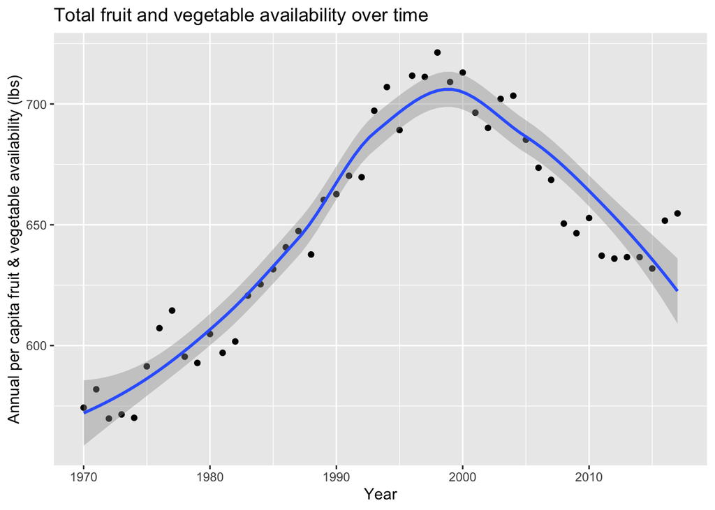

```r
dat_annual %>% ggplot(aes(x = year, y = total_fruit_veg)) + geom_point() +
  geom_smooth() + xlab('Year') + ylab('Annual per capita fruit & vegetable availability (lbs)') + ggtitle('Total fruit and vegetable availability over time')
```

It is important to note that this trend appears quadratic rather than linear. Now, let us check for approximate normality.

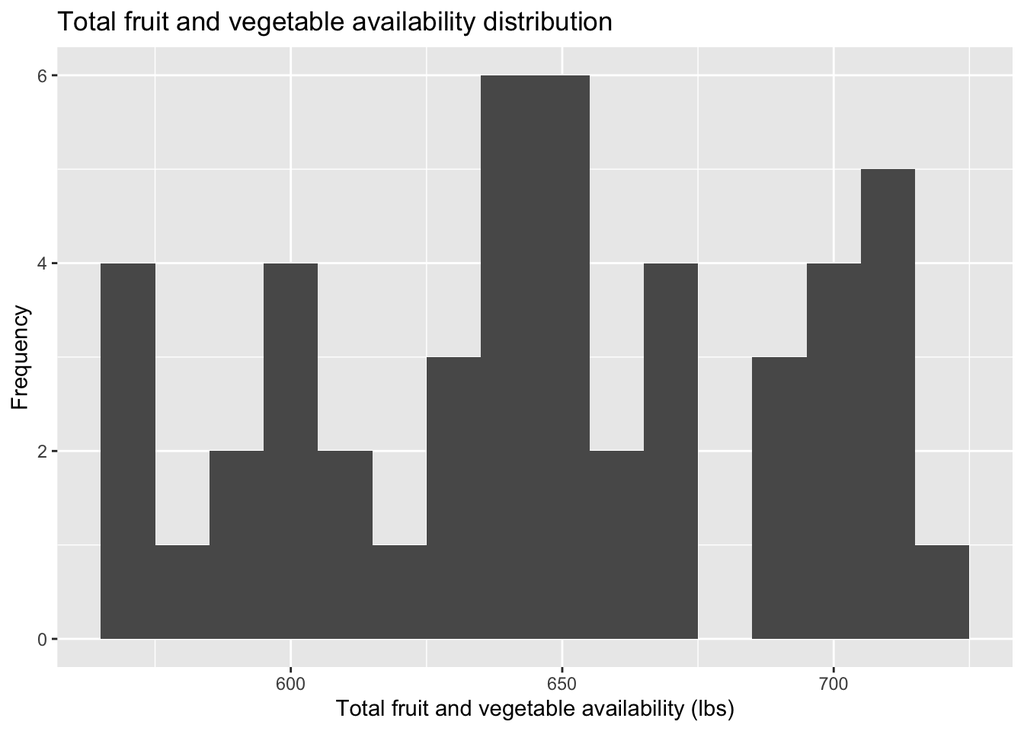

```r
dat_annual %>% ggplot(aes(x = total_fruit_veg)) + geom_histogram(binwidth = 10) + xlab('Total fruit and vegetable availability (lbs)') + ylab('Frequency') + ggtitle('Total fruit and vegetable availability distribution')
```

The data do not appear to follow a normal distribution. We can check if this is improved by using a transformation on our data, but note that this will make interpretation much more difficult.

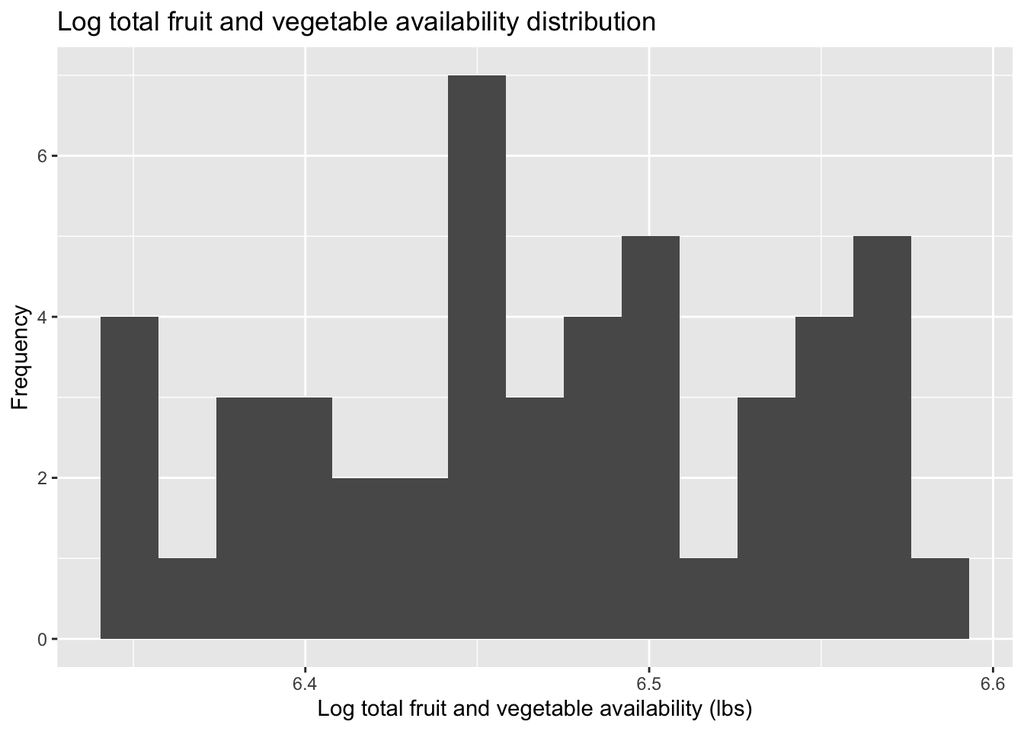

```r
dat_annual %>% ggplot(aes(x = log(total_fruit_veg))) + geom_histogram(bins = 15) + xlab('Log total fruit and vegetable availability (lbs)') + ylab('Frequency') + ggtitle('Log total fruit and vegetable availability distribution')
```

Unfortunately, it does not seem that this transformation improved the normality of our outcome variable. We must proceed with caution in the following regression analysis, as the assumptions of our model have been violated.

We will build a baseline simple linear regression model using only a year term, then build upon this model to improve the fit of the model to our data.

```r
lm_base <- lm(total_fruit_veg ~ year, data = dat_annual)

summary(lm_base)
```

```
##
## Call:
## lm(formula = total_fruit_veg ~ year, data = dat_annual)
##
## Residuals:
##     Min      1Q  Median      3Q     Max
## -56.405 -26.516  -3.776  27.157  65.712
##
## Coefficients:
##               Estimate Std. Error t value Pr(>|t|)
## (Intercept) -3189.7056   734.4966  -4.343 7.67e-05 ***
## year            1.9246     0.3684   5.224 4.14e-06 ***
## ---
## Signif. codes:  0 '***' 0.001 '**' 0.01 '*' 0.05 '.' 0.1 ' ' 1
##
## Residual standard error: 35.36 on 46 degrees of freedom
## Multiple R-squared:  0.3723, Adjusted R-squared:  0.3587
## F-statistic: 27.29 on 1 and 46 DF,  p-value: 4.135e-06
```

The model output shows that year is a statistically significant predictor of total fruit and vegetable availability. For each year, per capita total avaialbility increased on average by 1.9246 pounds. However, when we observe the plot of availability over time, the trend appears to be nonlinear. Thus, the linear term alone may not be fully appropriate. Let us consider how the model changes when we add a quadratic term.

```r
dat_annual$yearsq <- dat_annual$year^2

lm_yrsq <- lm(total_fruit_veg ~ year + yearsq, data = dat_annual)

summary(lm_yrsq)
```

```
##
## Call:
## lm(formula = total_fruit_veg ~ year + yearsq, data = dat_annual)
##
## Residuals:
##     Min      1Q  Median      3Q     Max
## -33.059 -16.743  -4.632  15.280  37.043
##
## Coefficients:
##               Estimate Std. Error t value Pr(>|t|)
## (Intercept) -6.668e+05  6.711e+04  -9.937 6.34e-13 ***
## year         6.678e+02  6.733e+01   9.918 6.73e-13 ***
## yearsq      -1.670e-01  1.689e-02  -9.889 7.36e-13 ***
## ---
## Signif. codes:  0 '***' 0.001 '**' 0.01 '*' 0.05 '.' 0.1 ' ' 1
##
## Residual standard error: 20.07 on 45 degrees of freedom
## Multiple R-squared:  0.8022, Adjusted R-squared:  0.7934
## F-statistic: 91.25 on 2 and 45 DF,  p-value: < 2.2e-16
```

By simply adding the age squared term, we find that the adjusted R-squared increases from 0.359 to 0.793. Further, both of the coefficients for year and year squared are statistically significant. We should likely keep the year squared term in our model going forward since this appears to be the most appropriate way to model the effect of time. Further, let us observe the plot of the residuals for this model.

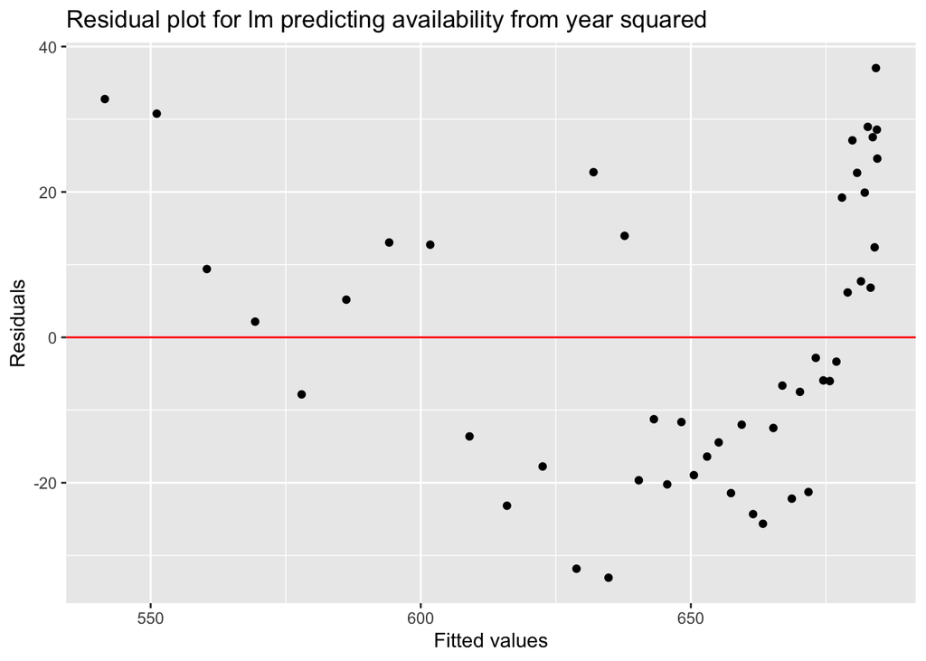

```r
p <- ggplot(data = dat_annual, aes(x = fitted(lm_yrsq), y = resid(lm_yrsq))) + geom_point() + geom_hline(yintercept = 0, color = 'red') + xlab('Fitted values') + ylab('Residuals') + ggtitle('Residual plot for lm predicting availability from year squared')

p
```

Most of the fitted values are greater than 650, which makes it difficult to assess if the equal variance assumption is met. In a larger sample, we may be able to gain a better intuition of how the residuals are distributed.

Let us now consider how the model performs when we adjust for each potential covariate from the dataset.

```r
lm_full <- lm(total_fruit_veg ~ year + yearsq + diabetes_percent + farm_income + unemployment + healthcare_percgdp + life_expectancy + population + gdp, data = dat_annual)

summary(lm_full)
```

```
##
## Call:
## lm(formula = total_fruit_veg ~ year + yearsq + diabetes_percent +
##     farm_income + unemployment + healthcare_percgdp + life_expectancy +
##     population + gdp, data = dat_annual)
##
## Residuals:
##      Min       1Q   Median       3Q      Max
## -20.5493  -5.4786  -0.8719   5.1807  24.8680
##
## Coefficients:
##                      Estimate Std. Error t value Pr(>|t|)
## (Intercept)        -1.078e+06  4.589e+05  -2.349   0.0264 *
## year                1.106e+03  4.624e+02   2.391   0.0241 *
## yearsq             -2.837e-01  1.164e-01  -2.438   0.0216 *
## diabetes_percent   -2.727e+01  1.351e+01  -2.019   0.0535 .
## farm_income         5.479e-08  2.058e-07   0.266   0.7921
## unemployment       -7.526e-01  5.714e+00  -0.132   0.8962
## healthcare_percgdp  2.691e+00  1.074e+01   0.251   0.8040
## life_expectancy    -1.853e+01  1.746e+01  -1.061   0.2980
## population          1.370e-05  3.982e-06   3.441   0.0019 **
## gdp                -1.345e-11  2.480e-11  -0.542   0.5921
## ---
## Signif. codes:  0 '***' 0.001 '**' 0.01 '*' 0.05 '.' 0.1 ' ' 1
##
## Residual standard error: 12.33 on 27 degrees of freedom
##   (11 observations deleted due to missingness)
## Multiple R-squared:  0.937,  Adjusted R-squared:  0.916
## F-statistic:  44.6 on 9 and 27 DF,  p-value: 6.666e-14
```

We find that the model explains roughly 92% of the variability in total per capita fruit and vegetable availbility, as denoted by the adjusted R-squared value. This is quite impressive! However, as discussed above, many of the predictors were correlated with each other. Let us use a model which keeps only 2 of these correlated variables, diabetes prevalence and population, as they had the lowest p-values. We may now observe the residual plot for this model.

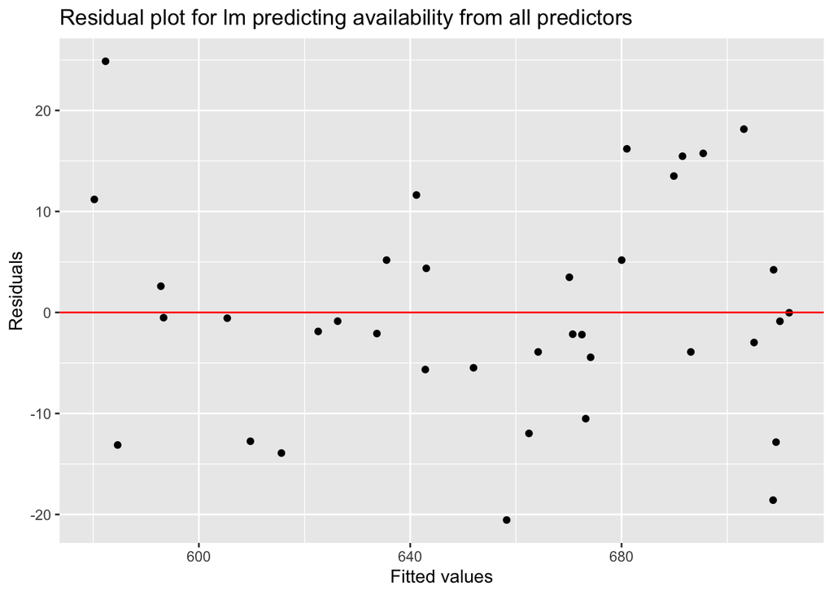

```r
p <- ggplot(data = dat_annual[complete.cases(dat_annual),], aes(x = fitted(lm_full), y = resid(lm_full))) + geom_point() + geom_hline(yintercept = 0, color = 'red') + xlab('Fitted values') + ylab('Residuals') + ggtitle('Residual plot for lm predicting availability from all predictors')

p
```

There appears to be random scatter among the residuals. However, the small sample size still makes it difficult to assess this assumption fully.

```r
lm_reduced <- lm(total_fruit_veg ~ year + yearsq + diabetes_percent + farm_income + unemployment + population, data = dat_annual)

summary(lm_reduced)
```

```
##
## Call:
## lm(formula = total_fruit_veg ~ year + yearsq + diabetes_percent +
##     farm_income + unemployment + population, data = dat_annual)
##
## Residuals:
##     Min      1Q  Median      3Q     Max
## -24.183  -6.081  -1.725   3.895  24.366
##
## Coefficients:
##                    Estimate Std. Error t value Pr(>|t|)
## (Intercept)      -4.834e+05  1.568e+05  -3.083  0.00405 **
## year              5.024e+02  1.578e+02   3.184  0.00310 **
## yearsq           -1.308e-01  3.972e-02  -3.294  0.00231 **
## diabetes_percent -4.458e+01  9.620e+00  -4.634 5.09e-05 ***
## farm_income      -1.014e-07  1.084e-07  -0.935  0.35635
## unemployment     -5.853e-01  1.640e+00  -0.357  0.72343
## population        1.032e-05  2.068e-06   4.991 1.76e-05 ***
## ---
## Signif. codes:  0 '***' 0.001 '**' 0.01 '*' 0.05 '.' 0.1 ' ' 1
##
## Residual standard error: 11.99 on 34 degrees of freedom
##   (7 observations deleted due to missingness)
## Multiple R-squared:  0.9269, Adjusted R-squared:  0.914
## F-statistic: 71.82 on 6 and 34 DF,  p-value: < 2.2e-16
```

Interestingly, the adjusted R-squared has only decreased slightly, changing from 0.916 to 0.914. Let us now observe how the model performance changes if we remove population, leaving no predictors which are correlated with each other.

```r
lm_reduced2 <- lm(total_fruit_veg ~ year + yearsq + diabetes_percent + farm_income + unemployment, data = dat_annual)

summary(lm_reduced2)
```

```
##
## Call:
## lm(formula = total_fruit_veg ~ year + yearsq + diabetes_percent +
##     farm_income + unemployment, data = dat_annual)
##
## Residuals:
##     Min      1Q  Median      3Q     Max
## -34.374 -10.362  -3.482  13.706  31.631
##
## Coefficients:
##                    Estimate Std. Error t value Pr(>|t|)
## (Intercept)      -5.520e+05  2.027e+05  -2.724   0.0100 *
## year              5.507e+02  2.043e+02   2.695   0.0107 *
## yearsq           -1.371e-01  5.150e-02  -2.663   0.0116 *
## diabetes_percent -1.354e+01  9.522e+00  -1.422   0.1639
## farm_income      -9.882e-08  1.407e-07  -0.702   0.4870
## unemployment     -4.825e+00  1.821e+00  -2.650   0.0120 *
## ---
## Signif. codes:  0 '***' 0.001 '**' 0.01 '*' 0.05 '.' 0.1 ' ' 1
##
## Residual standard error: 15.55 on 35 degrees of freedom
##   (7 observations deleted due to missingness)
## Multiple R-squared:  0.8733, Adjusted R-squared:  0.8552
## F-statistic: 48.24 on 5 and 35 DF,  p-value: 1.005e-14
```

The adjusted R-squared has reduced even further to 0.8552. Let us consider the residual plot for this model.

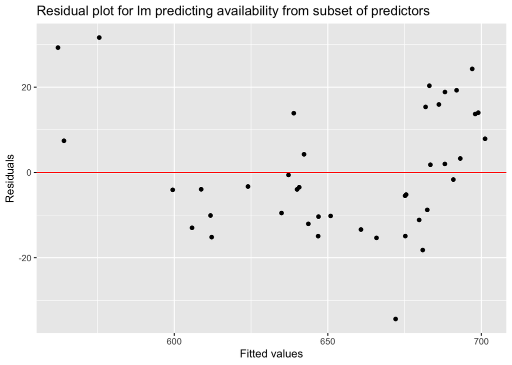

```r
p <- ggplot(data = dat_annual[!is.na(dat_annual$diabetes_percent) & !is.na(dat_annual$unemployment),], aes(x = fitted(lm_reduced2), y = resid(lm_reduced2))) + geom_point() + geom_hline(yintercept = 0, color = 'red') + xlab('Fitted values') + ylab('Residuals') + ggtitle('Residual plot for lm predicting availability from subset of predictors')

p
```

In selecting the most appropriate model, we must keep in mind that many of the predictors are correlated with each other and the outcome variable does not follow a normal distribution. We must also remember that the sample size is quite small, so it will be important to investigate how these trends may or may not hold for larger datasets, such as ones which include data from other countries. The high adjusted R-squared in the full model may simply be a case of overfitting.

# Interactive Data Visualization

We will build a shiny app to allow customized visualizations as follows:

We begin by installing the necessary packages for shiny.

```r
if(!require(shiny)) install.packages('shiny')
library(shiny)
if(!require(shinythemes)) install.packages('shinythemes')
library(shinythemes)
```

As a special feature, we will install a package that allows us to plot emojis.

```r
devtools::install_github("dill/emoGG")
library(emoGG)
```

As a sample, we will plot the availability of bananas over time.

```r
froot <- '1f34c'

dat_series %>% filter(fruit == 'bananas') %>% ggplot(aes(x = year, y = value)) + geom_emoji(emoji = '1f34c') + xlab('Year') + ylab('Banana availability (lbs)') + ggtitle('Banana availability over time')
```

[output not shown]

We will now create two dataframes with cleaner variable names for use in the Shiny app.

```r
var_names <- c('Total Fresh Fruit Availability (lbs)' = 'fruit_fresh',
               'Total Processed Fruit Availability (lbs)' = 'fruit_processed',
               'Total Fresh Vegetable Availability (lbs)' = 'veg_fresh',
               'Total Processed Vegetable Availability (lbs)' = 'veg_processed',
               'Total Fruit Availability (lbs)' = 'total_fruit',
               'Total Vegetable Availability (lbs)' = 'total_veg',
               'Total Fruit and Vegetable Availability (lbs)' = 'total_fruit_veg',
               'Diabetes Prevalence (%)' = 'diabetes_percent',
               'Average Annual Farm Income ($)' = 'farm_income',
               'Annual Unemployment Rate (%)' = 'unemployment',
               'Percent GDP Spending on Healthcare' = 'healthcare_percgdp',
               'Average Life Expectancy (yrs)' = 'life_expectancy',
               'Population' = 'population',
               'GDP' = 'gdp')

var_names
```

```
##         Total Fresh Fruit Availability (lbs)
##                                "fruit_fresh"
##     Total Processed Fruit Availability (lbs)
##                            "fruit_processed"
##     Total Fresh Vegetable Availability (lbs)
##                                  "veg_fresh"
## Total Processed Vegetable Availability (lbs)
##                              "veg_processed"
##               Total Fruit Availability (lbs)
##                                "total_fruit"
##           Total Vegetable Availability (lbs)
##                                  "total_veg"
## Total Fruit and Vegetable Availability (lbs)
##                            "total_fruit_veg"
##                      Diabetes Prevalence (%)
##                           "diabetes_percent"
##               Average Annual Farm Income ($)
##                                "farm_income"
##                 Annual Unemployment Rate (%)
##                               "unemployment"
##           Percent GDP Spending on Healthcare
##                         "healthcare_percgdp"
##                Average Life Expectancy (yrs)
##                            "life_expectancy"
##                                   Population
##                                 "population"
##                                          GDP
##                                        "gdp"
```

```r
names(var_names[which(var_names == 'life_expectancy')])
```

```
## [1] "Average Life Expectancy (yrs)"
```

```r
veg_names <- c('Apples' = 'apples',
               'Avocados' = 'avocados',
               'Bananas' = 'bananas',
               'Bell Peppers' = 'bellpeppers',
               'Broccoli' = 'broccoli',
               'Cabbage' = 'cabbage',
               'Carrots' = 'carrots',
               'Eggplant' = 'eggplant',
               'Grapes' = 'grapes',
               'Lemons' = 'lemons',
               'Mushrooms' = 'mushrooms',
               'Onions' = 'onions',
               'Oranges' = 'oranges',
               'Peaches' = 'peaches',
               'Pears' = 'pears',
               'Pineapples' = 'pineapples',
               'Potatoes' = 'potatoes',
               'Spinach' = 'spinach',
               'Tomatoes' = 'tomatoes',
               'Watermelon' = 'watermelon')

veg_names
```

```
##        Apples      Avocados       Bananas  Bell Peppers      Broccoli
##      "apples"    "avocados"     "bananas" "bellpeppers"    "broccoli"
##       Cabbage       Carrots      Eggplant        Grapes        Lemons
##     "cabbage"     "carrots"    "eggplant"      "grapes"      "lemons"
##     Mushrooms        Onions       Oranges       Peaches         Pears
##   "mushrooms"      "onions"     "oranges"     "peaches"       "pears"
##    Pineapples      Potatoes       Spinach      Tomatoes    Watermelon
##  "pineapples"    "potatoes"     "spinach"    "tomatoes"  "watermelon"
```

```r
names(veg_names[which(veg_names == 'bellpeppers')])
```

```
## [1] "Bell Peppers"
```

Now, the app is ready for use! Note: The code for the app is included in the markdown document and the app is embedded from shinyapps.io

Shiny applications not supported in static R Markdown documents

[interactive chart not shown]

# Conclusion

The interactive data visualization app helps us to uncover some interesting trends. While total fruit and vegetable consumption follows a roughly quadratic trend over the years, individual fruits and vegetables seem to follow very unique trends of their own. The avocado, for example, seems to have exponentially increased in availability over the last couple of decades, while peaches and pears have steadily been decreasing over time. Using this tool, we can develop further questions about the market and environmental forces that may be causing these trends. In regards to the pairwise correlations tool, the most surprising discovery is the weakness of the relationship between annual farm income and food availability. One possible explanation for this matter is the amount of variability between farms. Perhaps the growth in average farm income over time is driven by farmers who focus on certain crop types. This could especially influence the trend based on the weight of their crop since availability is measured in pounds. In all, this interactive tool can be used to investigate trends in the data and inform future investigations into agricultural and consumption trends.